[figure not shown]

# Programación Python - Concurrencia y Paralelismo - Fecha:20/08/2021

- Breve introducción de CPU, procesos y subprocesos para ayudarnos a comprender cómo funcionan la concurrencia y el paralelismo
- Proporcionar una descripción general de qué son la concurrencia y el paralelismo
- Explicar cuando aprovechar la concurrencia y el paralelismo
- Una introducción rápida sobre cómo funciona el GIL y por qué es necesario
- Diseñar e implementar aplicaciones teniendo en cuenta la concurrencia y el paralelismo y explicar cómo usar el multiproceso, asincio y multiprocesamiento en Python

[figure not shown]

## CPU

Podemos pensar en una CPU como el cerebro de una computadora.

Una CPU tiene sus ciclos que son esencialmente el tiempo que tarda la CPU en ejecutar una operación de procesador.

Un tic de un ciclo es una instrucción de código de 1 byte.

## Núcleos y procesos

Una CPU puede tener varios núcleos. Cada núcleo puede ejecutar varios procesos.

Un proceso son esencialmente las aplicaciones / las instrucciones de los programas que ejecutamos en nuestra computadora.

Cada proceso tiene su propio espacio de memoria. Si hacemos clic en la pestaña Procesos, veremos todos los procesos que se están ejecutando actualmente en nuestra computadora como iexplorer.exe, chrome.exe, PyCharm, Python.exe, etc.

En Python, cada proceso de Python tiene su propio intérprete de Python, espacio de memoria y el GIL (que explicaré en breve).

## Hilos

Además, cada proceso puede ejecutar varios subprocesos dentro de su contexto.

Un hilo es un conjunto de instrucciones informáticas codificadas. Cada hilo tiene su propio espacio de memoria. También tiene acceso a la memoria del proceso y a la información de contexto.

Cuando ejecutamos un proceso, como Python.exe, ejecuta el código dentro de su hilo principal. El hilo principal puede iniciar varios hilos. Posteriormente, un proceso puede iniciar varios subprocesos.

## Un ejemplo de cocina

Este ejemplo nos ayudará a comprender mejor los conceptos de concurrencia y paralelismo. Considere este escenario.

Es domingo por la mañana y espero que 10 de mis amigos visiten mi casa para almorzar. Tengo alrededor de 3 horas para cocinar una comida para mis 10 amigos.

Ahora, algunos de los pasos requieren más tiempo que otros.

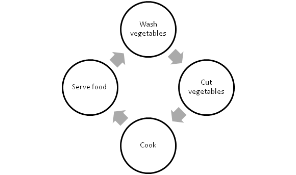

En total, llevaría aproximadamente 50 minutos cocinar la comida para uno de mis amigos. Ahora, repite el proceso 10 veces y me llevará 500 minutos. Eso es alrededor de 8 horas de cocción.

¡Estoy seguro de que puedo acelerarlo!

Pero espera, solo tengo 3 horas para hacer una tarea de 8 horas. ¿Cómo hago una tarea de 8 horas en 3 horas? ¿Puedo paralelizarlo?

La primera tarea para mí es comprender dónde está el cuello de botella. Dibujemos la secuencia de pasos en un papel para visualizar cómo y dónde está el cuello de botella:

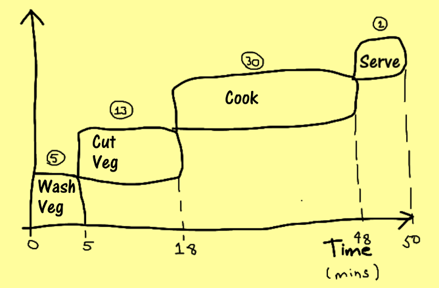

El paso para cocinar la comida tarda unos 30 minutos. El mayor cuello de botella para mí es que solo tengo una olla en casa donde puedo cocinar / hervir las verduras. Este es un escenario perfecto para ayudarme a ilustrar cómo podemos utilizar la concurrencia y el paralelismo para acelerar el rendimiento. No estoy seguro de dónde leí un ejemplo similar y se quedó en mi cabeza, así que basaré mi artículo en él. De vuelta al mundo del software

Usaré el escenario que he explicado anteriormente para explicar qué son la concurrencia y el paralelismo y cómo pueden ayudar.

Por el momento, soy el único chef que está preparando la comida.

- Podemos considerar el proceso de cocción como una aplicación de Python.
- Cada uno de los pasos de cocción que describí anteriormente son esencialmente las funciones que podemos ejecutar en nuestra aplicación Python.
- El chef, es decir, yo mismo, es un proceso de Python y todos estos pasos se ejecutan dentro del hilo principal.

## Acelerando el proceso de cocción

Hay varias formas de acelerar el proceso de cocción, como:

- Puedo fragmentar / dividir toda la carga de trabajo en dos conjuntos de tareas.

Por ejemplo, el primer conjunto puede contener los pasos de preparación de alimentos para 5 de mis amigos, mientras que el segundo conjunto puede contener los pasos de preparación de alimentos para los 5 amigos restantes.

Luego puedo trabajar en el primer conjunto mientras otro chef (proceso) puede tomar la segunda tarea y cocinar la comida en paralelo conmigo.

- También podría comprar ollas adicionales y cocinar las verduras simultáneamente mientras lavo y corto las verduras para el siguiente plato.

Entendamos cómo la concurrencia y el paralelismo encajan allí.

## ¿Qué son la concurrencia y el paralelismo?

Entendamos estos dos conceptos.

## Paralelismo

Comprender el paralelismo es lo más simple. La ejecución paralela significa ejecutar múltiples conjuntos de instrucciones al mismo tiempo en un proceso completamente diferente. Dentro de cada proceso, podemos optar por ejecutar los pasos de forma sincrónica o asincrónica.

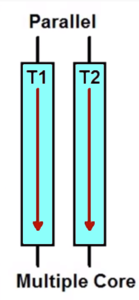

Con respecto al escenario del almuerzo anterior, si uno de mis amigos ayuda a cocinar el almuerzo para 5 de mis amigos en su casa mientras yo cocino el almuerzo para los otros cinco amigos en mi casa, entonces es como si hubiera dos procesos ejecutándose en paralelo. Eso se conoce como paralelismo en el mundo del software.

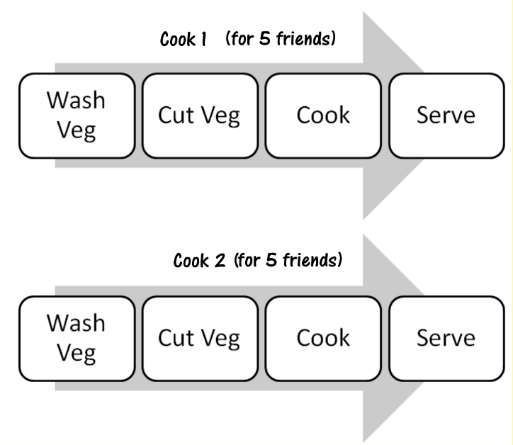

En aras de la simplicidad, podemos concluir que ejecutar los procesos de cocción en paralelo nos ayudará a preparar el almuerzo para 10 de mis amigos en aproximadamente 4 horas. Hemos reducido el tiempo a la mitad. ¡No está mal, verdad!

Por lo tanto, el paralelismo simplemente significa dividir el trabajo en múltiples conjuntos y ejecutar múltiples procesos al mismo tiempo (mapa). Finalmente, podemos agregar los resultados juntos (reducir). Al igual que no estoy compartiendo mi cocina y hornillo con mi amigo, los procesos no tienen por qué compartir el recuerdo.

Una información muy importante a tener en cuenta son las razones para tener una máquina de varios núcleos. Siempre que creamos un nuevo proceso de Python, el proceso ejecuta el código en su propio intérprete de Python en un solo núcleo. Para que podamos ejecutar múltiples procesos, necesitamos tener una máquina de múltiples núcleos.

El procesamiento paralelo implica ejecutar un proceso en cada uno de los núcleos de una máquina.

Como resultado, el paralelismo en Python consiste en crear múltiples procesos para ejecutar las operaciones vinculadas a la CPU en paralelo.

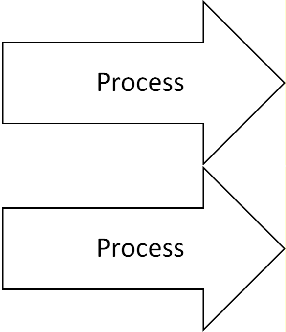

Crear un nuevo proceso es una tarea cara. Por lo tanto, debemos tener mucho cuidado y asegurarnos de que estamos intentando ejecutar una operación de larga duración vinculada a la CPU (y no a IO).

## Concurrencia

La concurrencia es ligeramente diferente. La simultaneidad también se usa para aumentar el rendimiento general de una aplicación, pero se usa para resolver un problema diferente. Explicaré el concepto ahora.

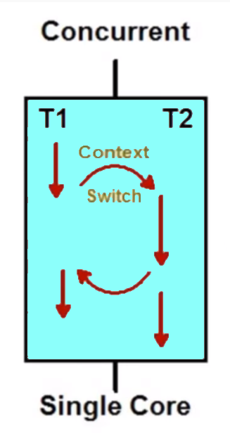

Con respecto al escenario del almuerzo anterior, consideremos que todos mis amigos no están disponibles para ayudarme a cocinar el almuerzo. En cambio, puedo optar por la segunda opción y comprar varias cocinas. Cada olla puede verse como un hilo.

Ahora puedo lavar y cortar las verduras en serie como antes. Sin embargo, cuando se trata del paso de cocinar / calentar las verduras, puedo calentar las verduras de cada plato en varias ollas al mismo tiempo.

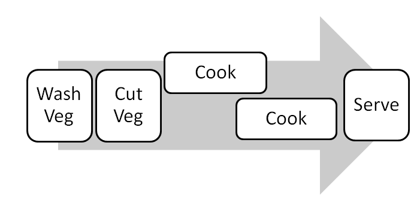

La simultaneidad es excelente para operaciones vinculadas a E / S, como leer un archivo o comunicarse a través de una red.

## Repasemos técnicamente

Consideremos que hay una serie de tareas a ejecutar en un solo proceso. Estas tareas pueden implicar leer un archivo o llamar a un servicio web externo. Se trata esencialmente de llamadas de red o de E / S. Podemos acelerar el tiempo que tarda nuestra aplicación en completar varias llamadas de E / S creando varios subprocesos.

Como ejemplo, podemos iniciar una tarea en un hilo. Mientras el primer hilo se ejecuta y espera los datos de un recurso externo, podemos iniciar otra tarea en otro hilo.

## Evaluación de subprocesos

Los hilos son objetos un poco complicados. Evaluémoslos de cerca.

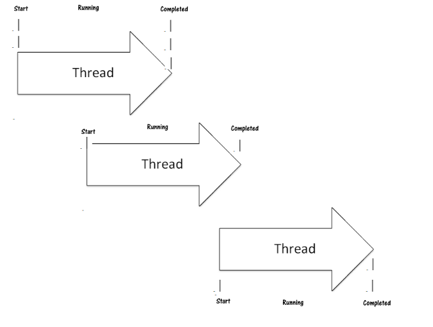

La imagen de arriba muestra una vista simplista de cómo se ejecutan los hilos.

En la imagen de arriba, hemos creado tres hilos. Inicialmente, comenzamos un hilo. Mientras el hilo se estaba ejecutando, comenzamos otro hilo. Mientras se ejecutaba el segundo hilo, el primer hilo se completó y comenzamos el tercer hilo. Finalmente, todos los hilos completaron su ejecución.

Podríamos haber ejecutado todos los subprocesos en una secuencia, pero ejecutarlos simultáneamente ahorró algo de tiempo (dondequiera que los subprocesos se hayan superpuesto).

**El punto clave de esta sección es que una aplicación puede ser concurrente y no paralela. Una aplicación puede ser paralela y no concurrente. Una aplicación no puede ser simultánea ni paralela y una aplicación puede ser simultánea y paralela.**

## ¿Cuándo deberíamos utilizar la concurrencia y / o el paralelismo?

Esto nos lleva al núcleo de la sección.

Al principio comprendimos que las operaciones vinculadas a la CPU requieren ciclos de CPU. Las operaciones de la CPU pueden incluir realizar operaciones matemáticas, manipulación de texto, procesamiento de imágenes, etc. Son pesados en la CPU. Podemos ver la utilización de la CPU aumentando en el Administrador de tareas cuando los ejecutamos.

En un nivel alto, si su aplicación Python está realizando operaciones vinculadas a la CPU, como el procesamiento de números o la manipulación de texto, busque el paralelismo. La concurrencia no producirá muchos beneficios en esos escenarios.

A veces, tenemos que comunicarnos y obtener datos de una fuente externa. Esta fuente podría ser una base de datos que se ejecuta en otro servidor, un servicio web o incluso un archivo que reside en un sistema de archivos compartido o incluso en una cola de tareas distribuida. Estos son ejemplos de operaciones vinculadas a IO.

La clave a tener en cuenta es que cualquier acción que requiera comunicarse con el hardware (como sockets) implica comunicarse con el kernel de su máquina. Y las operaciones realizadas por el kernel son más lentas que las operaciones de una CPU.

Como resultado, la mayoría de las operaciones vinculadas a E / S permanecen en el estado de espera de E / S. Por ejemplo, si queremos consultar un servicio web externo, la función permanecerá en estado de espera hasta que obtenga los resultados del servicio web. También hay una sobrecarga de cambio de contexto. El cambio de contexto consiste en guardar el estado de la tarea actual y cambiar el contexto a la otra tarea.

La mayoría de las operaciones vinculadas de E / S requieren comunicarse con los recursos externos, como hardware o red, como instancia. Cuando ejecutamos las operaciones vinculadas de E / S, veremos un aumento en la utilización de la red y el disco en el Administrador de tareas.

Si su aplicación Python está realizando operaciones vinculadas a IO, como consultar un servicio web o leer archivos grandes, busque opciones de concurrencia. Si ejecutamos dos operaciones vinculadas a la CPU como dos subprocesos, se ejecutarán secuencialmente y no obtendremos ningún beneficio en Python. En realidad, podrían terminar demorando más debido a la adquisición de bloqueo y el cambio de contexto.

Podemos usar la imagen a continuación para decidir si necesitamos un proceso o un hilo / asyncio:

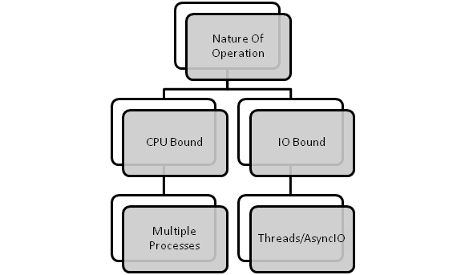

| Concurrencia | Paralelismo |
| --- | --- |
| 1. Es el mecanismo para ejecutar múltiples procesos al mismo tiempo no es necesario que sean simultáneos. | 1. Es la capacidad de dividir un proceso pesado en subtareas independientes más pequeñas y ejecutarlas simultáneamente. |
| 2. El cambio de contexto juega un papel importante en la implementación de la concurrencia. | 2. En el paralelismo, los subprocesos se ejecutan por separado, por lo que no hay sobrecarga de cambio de contexto. |
| 3. Se logra utilizando unidades de procesamiento simples o mediante un solo núcleo. | 3. Requiere múltiples unidades de procesamiento, ya que los procesos se ejecutan por separado en diferentes núcleos. |
| 4. Se ejecuta en un solo núcleo, por lo que se requiere menos hardware. | 4. La implementación requiere múltiples núcleos para cada uno de los procesos, por lo que el costo del hardware es comparativamente mayor aquí. |
| 5. Aumenta la cantidad de trabajo terminado a la vez y ayuda a disminuir considerablemente el tiempo de respuesta. | 5. Es responsable de aumentar el rendimiento del sistema y de una ejecución más rápida. |
| 6. La concurrencia se trata de lidiar con muchas cosas a la vez. | 6. Sin embargo, el paralelismo consiste en hacer muchas cosas al mismo tiempo. |

De hecho, para las operaciones vinculadas a IO, la ejecución de varios procesos podría resultar más lenta que si los ejecutamos secuencialmente debido al hecho de que la creación de procesos conlleva una sobrecarga.

Cada proceso de Python tiene su propio intérprete de Python y esto tiene una gran huella de memoria. La concurrencia es mejor para situaciones en las que se requiere eficiencia de recursos.

El mecanismo de bloqueo en Python se usa mucho durante la ejecución de subprocesos. Antes de explicar cómo ejecutar código Python simultáneamente y en paralelo, vale la pena mencionar qué es el bloqueo de intérprete global (GIL).

## Bloqueo de intérprete global de Python (GIL)

El GIL es uno de los conceptos más importantes que deben comprender los usuarios avanzados de Python.

Para comprender GIL, es importante recordar que el administrador de memoria de Python no es seguro para subprocesos. Como resultado, los subprocesos múltiples pueden actualizar el mismo objeto en la memoria. Esto puede terminar corrompiendo el estado de los objetos en una aplicación.

CPython se basa en código C y las estructuras internas del intérprete junto con las estructuras del código C no son seguras para subprocesos.

La clave a tener en cuenta es que los datos deben protegerse mediante el uso de mecanismos de bloqueo para que varios subprocesos no puedan dañar la memoria. Para resolver este problema, el intérprete de Python utiliza un candado, conocido como Global Interpreter Lock (GIL).

## El GIL es un candado adquirido por el intérprete de Python

https://bitybyte.github.io/Python-GIL/

Cada proceso de Python tiene un intérprete. Posteriormente, cada proceso tiene un GIL. Los ciclos de la CPU marcan rápido y, a veces, parece que los subprocesos se ejecutan al mismo tiempo cuando se ejecutan internamente en serie. Por lo tanto, el intérprete ejecuta el código de un solo hilo a la vez.

El intérprete coordina los subprocesos para que todos obtengan la parte de los ciclos de la CPU. Esto lo logra el intérprete utilizando el GIL.

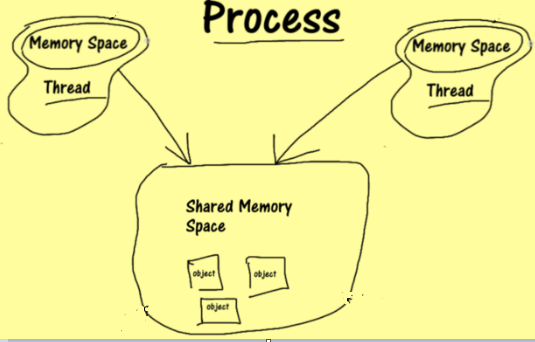

En la imagen de arriba, tenemos un proceso que tiene dos hilos. Cada hilo tiene acceso al espacio de memoria compartida. Cada hilo tiene su propio espacio de memoria local.

El intérprete utiliza el GIL para adquirir un bloqueo en un hilo. En consecuencia, solo se ejecuta un hilo en un momento dado, incluso si ejecutamos la aplicación en una máquina de múltiples núcleos.

Por lo tanto, GIL asegura que solo un subproceso pueda ejecutar el intérprete en un momento dado.

Todos los demás subprocesos permanecen en estado de espera hasta que se libera el GIL. Esto se conoce como mecanismo de división del tiempo. Cada hilo obtiene alrededor de 5 ms de tiempo de ejecución y el intérprete libera el bloqueo del hilo para que pueda ejecutarse.

Debido al hecho de que cada proceso tiene un GIL para controlar la ejecución de subprocesos, a menudo buscamos usar múltiples procesos sobre múltiples subprocesos para acelerar las operaciones vinculadas a la CPU.

Esta es la razón por la que GIL no es tan popular entre los usuarios de Python.

Por lo tanto, GIL evita que los subprocesos vinculados a la CPU se ejecuten en paralelo. Esto no significa que no podamos usar hilos en Python. Debemos usar subprocesos cuando estamos realizando múltiples operaciones vinculadas de E / S. Esto incluye llamadas de red, carga de datos desde el disco, operaciones basadas en la interfaz de usuario, comunicación con fuentes externas.

Como resultado, GIL será adquirido por un hilo que requiere obtener los datos de una fuente externa. Posteriormente, se libera el bloqueo y es adquirido por otro hilo que necesita ejecutar un código vinculado a IO. Cuando el primer subproceso recupera el GIL, habría recibido los datos.

Como resultado, los subprocesos múltiples mejoran el rendimiento de la aplicación Python para operaciones vinculadas a IO, aunque el intérprete solo ejecuta el código para un subproceso a la vez.

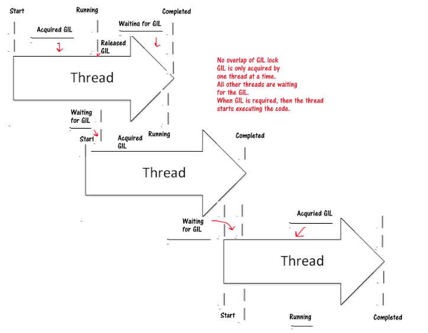

La imagen de arriba ilustra que el GIL solo es adquirido por un hilo a la vez. Todos los demás subprocesos permanecen en estado de espera hasta que se adquiere el GIL. Adquirir / liberar el GIL termina ralentizando la aplicación.

Las aplicaciones concurrentes suelen ser menos costosas que las aplicaciones paralelas porque la creación de nuevos procesos es más costosa que la creación de nuevos hilos.

Es importante bloquear los objetos globales / compartidos en su código Python si elige optar por el enfoque de concurrencia.

## ¿Por qué necesitamos bloquear objetos cuando solo se ejecuta un hilo a la vez?

Probablemente nos estemos preguntando por qué necesitamos bloquear los objetos si GIL asegura que solo se puede ejecutar un hilo a la vez.

El intérprete se encargará de los objetos internos de Python utilizando GIL, pero nosotros debemos cuidar los objetos que hemos creado nosotros mismos. Los subprocesos comparten el espacio de memoria global y, por lo tanto, pueden sobrescribir la misma memoria.

Aunque los subprocesos se ejecutan una vez a la vez y, por lo tanto, el intérprete y sus objetos internos están a cargo del GIL, los objetos personalizados globales que creamos en la aplicación son todos compartidos por todos los subprocesos dentro de un proceso. . Es necesario que bloqueemos estos objetos globales para garantizar que no enfrentamos resultados inesperados.

La siguiente imagen muestra que cada hilo tiene su espacio de memoria local y acceso al espacio de memoria compartida. El espacio de memoria compartida es global para los subprocesos y podemos crear nuestros objetos personalizados allí. Es necesario que estos objetos los bloqueemos nosotros mismos.

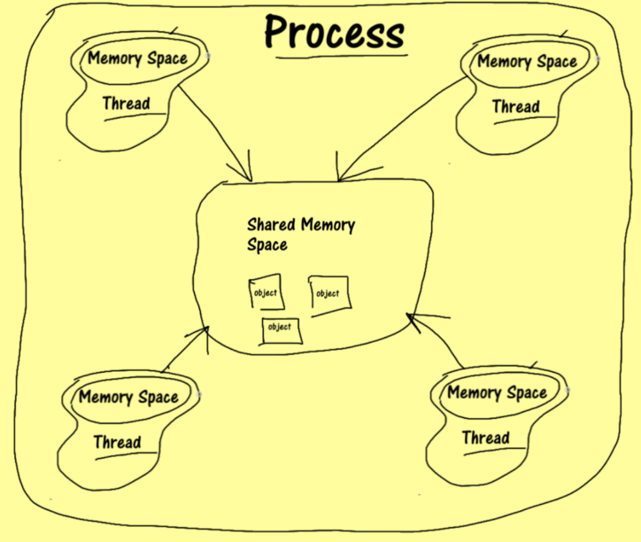

Como ejemplo, podemos usar los objetos threading.Lock, threading.RLock o threading.Semaphore para bloquear los objetos.

Para comprender los motivos en profundidad, considere el fragmento del código a continuación:

```python
i = 0
for j in range(200):
    if i == 2:
        print(" ValueError('i is 2')")
    else:
        i = i + 1
```

El objeto i está en el espacio de memoria global, por lo tanto, es accesible para todos los subprocesos.

Consideremos que hay dos subprocesos que ejecutan el código. El GIL se asegurará de que solo el hilo pueda ejecutar las instrucciones (línea de código) a la vez e incluso con el GIL, terminaremos teniendo problemas de corrupción de memoria como se explica a continuación.

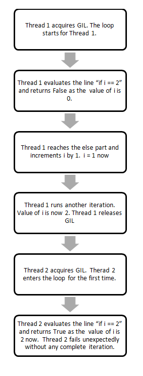

La imagen de arriba ilustra cómo los dos subprocesos pueden dañar el estado de la memoria.

Las dos soluciones recomendadas serían:

- Cree una variable local i para que cada hilo tenga su propio objeto en su espacio de memoria local, ya sea pasando la variable como argumento al hilo o declarándola dentro de la función.
- Utilice el mecanismo de bloqueo en Python para bloquear la variable. Python ofrece una serie de objetos de bloqueo. Si varios subprocesos comparten un objeto, entonces debemos usar los objetos threading.Lock, threading.RLock, threading.Semaphore, etc. para asegurarnos de que los objetos no se corrompan como se muestra a continuación:

```python
lock = mulithreading.Lock()
def func():
    lock.acquire()
    if i == 2:
       ...
    lock.release()
```

## ¿Cómo multiproceso en Python?

Voy a demostrar cómo podemos ejecutar operaciones IO creando múltiples subprocesos. Comenzaré presentando un ejemplo de la vida real que funciona de manera no concurrente / sincrónica.

## Enfoque sincrónico

El método siguiente llama a la biblioteca de finanzas de yahoo para 5 símbolos de empresa. Obtiene la información de cada una de las empresas de forma secuencial.

Luego, el código imprime el tiempo que tardó en obtener la información de las 5 empresas:

```python
import time
import ya
started = time.time()

def print_company_info(company):
    ticker = yf.Ticker(company)
    info = ticker.get_info()
    print(info)

companies = ['ABT', 'ABBV', 'ABMD', 'ATVI', 'ADBE']
for company in companies:
    print_company_info(company)


elapsed = time.time()

print('Time taken: :', elapsed-started)
#Time taken: : 67.12
```

Se trata de una operación vinculada de E / S que se realiza una vez para cada empresa. La función está en estado de espera la mayor parte del tiempo, ya que espera el resultado del servicio web externo de yahoo.

Por lo tanto, es un candidato ideal para aplicaciones concurrentes.

## Enfoque multiproceso

Python ofrece una biblioteca de subprocesos incorporada que nos permite ejecutar instrucciones de nuestro código al mismo tiempo. Hay varias formas de crear una aplicación multiproceso.

Mostraré una de las opciones más simples usando la clase ThreadPoolExecuter. La clase ThreadPoolExecuter está en el módulo concurrent.futures.

Nos permite usar un grupo de subprocesos y ejecutar llamadas a métodos. Podemos crear un ThreadPoolExecuter pasando el número máximo opcional de subprocesos de trabajo que se necesitan para ejecutar de forma asincrónica.

A partir de la versión 3.8, si no se proporciona un valor para el parámetro de trabajadores máximos, la biblioteca establece internamente el número de subprocesos en mínimo (32, CPU count + 4). Esto se basa en la suposición de que los subprocesos se utilizan principalmente para operaciones vinculadas de E / S y, como resultado, se conservan al menos 5 trabajadores para tareas vinculadas de E / S.

El valor del número de subprocesos debe seleccionarse cuidadosamente evaluando los recursos y cuánto tiempo toma cada una de las operaciones. La creación de subprocesos es una operación costosa, consume espacio de memoria adicional y hay una sobrecarga de cambio de contexto.

El fragmento de código muestra cómo podemos usar ThreadPoolExecuter:

```python
import time
import concurrent.futures
started = time.time()

companies = [’ABT’, 'ABBV’, 'ABMD’, 'ATVI’, 'ADBE’]

size = 5
with concurrent.futures.ThreadPoolExecutor(size) as thp:
    thp.map(print_company_info, companies)
elapsed = time.time()

print(’Time taken: :’, elapsed - started)
#Time taken: : 6.766068696975708
```

Luego ejecutamos el método map () en el ejecutor. El método del mapa toma la función que queremos ejecutar junto con un iterable. Luego, la función se ejecuta una vez para cada uno de los elementos del iterable.

La función se completó en 6,77 segundos. Esto es aproximadamente 10 veces más rápido que su contraparte síncrona.

Si desea saber más sobre la biblioteca de subprocesos, lea la documentación oficial de Python aquí .

## ¿Cómo AsyncIO en Python?

Python ofrece la biblioteca asyncio que nos permite realizar acciones mientras una tarea está en un estado de espera de E / S. La biblioteca permite a los codificadores de Python escribir código concurrente usando la sintaxis async / await mientras tienen control total sobre la ejecución de las corrutinas concurrentes.

La base de Async IO se basa en el objeto de bucle de eventos. Podemos pensar en el ciclo de eventos como una pila de funciones. El bucle de eventos es esencialmente el núcleo de cada operación de asyncio. Mantiene las funciones que se van a ejecutar y asegura que las funciones no se bloqueen entre sí.

Podemos declarar una función con la palabra clave async:

import asyncio async def main(): ....

La función se declara con la palabra clave async, lo que implica que devolverá el resultado en el futuro. Estas funciones se denominan objetos futuros. Se llama a una palabra clave await para esperar a que se complete la función. Esto hace que el objeto sea esperado.

Siempre que definimos una función con la palabra clave async, se crea una corrutina. Las corrutinas de Python se pueden esperar de otras corrutinas.

Por lo tanto, podemos crear una corrutina declarando una función con la palabra clave async y luego esperar en ella. La palabra clave await permite que el bucle de eventos maneje el control y bloquea el código que indica que está esperando el resultado.

El fragmento de código a continuación ejecutará el código para consultar la biblioteca de finanzas de Yahoo de manera simultánea utilizando la biblioteca asyncio.

```python
import asyncio
import time
def print_company_info(company):
    ticker = yf.Ticker(company)
    info = ticker.get_info()
    print(info)
companies = ['ABT', 'ABBV', 'ABMD', 'ATVI', 'ADBE']
tasks = []
event_loop = asyncio.get_event_loop()
for company in companies:
    #Not calling the functions here, we are storing an awaitable functions in an array
    tasks.append((print_company_info(company)))
started = time.time()
event_loop.run_until_complete(asyncio.wait(tasks))
elapsed = time.time()
#Time taken: : 6.34
```

1. Comenzamos importando la biblioteca asyncio
2. Luego creamos nuestra función print_company_info () que toma el símbolo de la empresa como parámetro.
3. Luego obtuvimos el bucle de eventos actual. El sistema operativo creará un nuevo bucle de eventos si no se establece un bucle de eventos.
4. Luego recorrimos la colección de empresas. Dentro de cada iteración, creamos una tarea. Las tareas se utilizan para programar corrutinas al mismo tiempo.
5. Finalmente, ejecutamos el método run_until_complete () para ejecutar todas las tareas hasta que se hayan completado. Pasamos asyncio.wait () como parámetro. Volverá cuando se hayan completado todas las tareas.

Si desea los valores de retorno, también puede usar asyncio.gather(*tasks) También podemos declarar cada método con @ asyncio.coroutine decorator.

La biblioteca y su funcionalidad se documentan en detalle aquí. https://docs.python.org/3/library/asyncio.html

## Asyncio Over Threads

Algunos puntos a tener en cuenta:

- Asyncio es la opción preferida sobre los subprocesos para operaciones IO de larga duración. Asyncio es una mejor opción si queremos compartir recursos sin perder tiempo en hacer que nuestro código sea seguro para subprocesos.
- Los hilos pueden ser propensos a errores. Si sus operaciones vinculadas a E / S son rápidas, elija multiproceso.
- Asyncio es multitarea cooperativa y es adecuado para operaciones lentas vinculadas a IO.

Finalmente, quería explicar cómo funciona el paralelismo en Python.

La mayoría de las tareas de limpieza de datos y entrenamiento de modelos en la ciencia de datos están vinculadas a la CPU por naturaleza. Podemos mejorar el rendimiento de las operaciones vinculadas a la CPU en una máquina multinúcleo utilizando las funciones de multiprocesamiento de Python.

Python, su implementación CPython en particular, no usa múltiples CPU de forma predeterminada.

En teoría, podemos utilizar todos los núcleos de nuestra máquina y completar una operación de CPU de larga duración dentro de ¹ / ₙ del tiempo que toma en una máquina de un solo núcleo, donde n es la cantidad de núcleos en nuestra máquina. En la práctica, tenemos que tomarnos el tiempo necesario para crear una instancia de subproceso, teniendo en cuenta la memoria que consume entre otras operaciones, pero en general, es más rápido ejecutar múltiples operaciones vinculadas a CPU de larga ejecución en paralelo que ejecutar las operaciones en serie.

Python tiene una poderosa biblioteca de multiprocesamiento. Nos permite generar múltiples procesos. Los procesos en Python no están sujetos a GIL.

Además, los procesos no comparten el contexto de la memoria y, por lo tanto, no es más fácil corromper los objetos de la memoria.

Usando el módulo de multiprocesamiento, también podemos compartir datos dentro de los procesos. Sin embargo, recomendaría que lo evitemos, si podemos, para evitar la sobrecarga de comunicación.

Hay dos objetos principales: Pool y Process.

Un grupo es un envoltorio alrededor de un proceso / hilo. Se llama Pool porque agrupa a varios trabajadores para compartir un gran conjunto de trabajo y es capaz de agregar el resultado. El grupo es ideal para dividir el trabajo entre varios procesos y luego agregar los resultados (mapa / patrón de reducción).

Cada subproceso tiene su propia memoria privada, intérprete de Python, GIL y un único hilo principal.

Pool.map () devuelve una colección donde cada elemento de la colección es el valor de retorno de la función que queríamos ejecutar en un subproceso. De forma predeterminada, la cantidad de elementos se divide en unidades de trabajo independientes de modo que, en total, tengamos tantos fragmentos de datos como la cantidad de CPU físicas.

El objeto de proceso puede ejecutar todas las tareas. Por lo tanto, si tenemos un número relativamente menor de tareas, podemos optar por crear un objeto de proceso para manejarlas. Sin embargo, si necesitamos ejecutar una gran cantidad de tareas y estamos preocupados por la falta de memoria, entonces deberíamos usar el objeto Pool. El objeto Pool asegura que solo se esté ejecutando el número elegido de procesos en un momento dado.

## Cómo compartir datos entre procesos

Podemos compartir los datos pasándolos como un argumento de la función a cada uno de los procesos, pero resultaría en duplicar la huella de memoria.

1. Si queremos enviar datos entre procesos, podemos utilizar los objetos multiprocesamiento.Queue. Los objetos de la cola recogen los objetos y luego los despegan cuando se reciben en un proceso. También podemos usar los objetos multiprocessing.Manager (). Queue () y pasarlos como argumentos a un objeto multiprocessing.Process (args = queue) para la intercomunicación entre los procesos.
2. La tubería también se puede utilizar para la comunicación unidireccional y bidireccional entre procesos.
3. Podemos usar una cola para un escenario de publicación / suscripción.
4. También se puede utilizar un administrador para compartir objetos entre procesos.
5. También podemos utilizar multiprocessing.Array y multiprocessing.Value para compartir bloques de memoria entre procesos.

También podemos paralelizar tareas vinculadas de E / S utilizando el módulo multiprocessing.dummy; de multiprocessing.dummy import Pool.

Escribamos el código Python para ilustrar cómo funciona el multiprocesamiento en Python. El fragmento de código a continuación muestra una función llamada incremento ().

Incrementa una variable en un millón de veces. Vamos a ejecutar la función 100 veces en serie y evaluar la operación enlazada de CPU de larga ejecución.

## Enfoque en serie

```python
import time

def increment(input):
    for i in range(1000000):
        input = input + 1

if __name__ == "__main__":
    inputs = [1] * 100

    started = time.time()
    for i in inputs:
        increment(i)

    # Time taken: : 35.019266843795776
    elapsed = time.time()

    print('Time taken Sequential:', elapsed - started)
# Time taken: : 35.019266843795776
```

Podemos bifurcarlo creando múltiples procesos secundarios para acelerar el rendimiento.

## Enfoque de multiprocesamiento

Hay varias opciones para ejecutar una aplicación en modo paralelo. Podemos usar la biblioteca de multiprocesamiento mediante la cual podemos usar el objeto Process () o Pool () como instancia o podemos usar el módulo concurrent.futures.

En el fragmento de código a continuación, he creado un objeto Pool con 8 procesos de trabajo para crear. La función increment () se puede descargar a los procesos de trabajo. Como resultado, solo se crearán 8 procesos para ejecutar la función increment (). Cuando finalicen la ejecución, el lote de las siguientes 8 tareas se incorporará a los 8 procesos y así sucesivamente.

```python
import time
from multiprocessing import Pool


def increment(input):
    for i in range(1000000):
        input = input + 1

if __name__ == "__main__":
    inputs = [1] * 100
    pool = Pool(8)
    started = time.time()
    pool.map(increment, inputs)


    elapsed = time.time()
    print('Time taken MultiProcess :', elapsed - started)

    pool.close()
# Time Taken 8 processes = 7.562885284423828
```

Sugerencia: Podemos ver la pestaña Procesos del Administrador de tareas para ver cuántos de los Procesos se están ejecutando en un momento determinado. Habrá 9 procesos en ejecución para el fragmento anterior (8 subprocesos y 1 proceso principal de python.exe).

También podemos usar la clase ProcessPoolExecuter que usa un grupo de procesos para ejecutar llamadas de forma asincrónica. Utiliza la biblioteca de multiprocesamiento debajo del capó. Es importante llamar al método join () para asegurarse de que los procesos hayan completado la ejecución.

Consejo: también podemos hacer que los procesos sean concurrentes (sin bloqueo) ejecutando el método pool.apply_async ().

Para comprender el paquete en detalle, lea esta documentación oficial

## Consejos

- Considere el hecho de que depurar un sistema paralelo y concurrente es una tarea difícil. Durante la depuración, recomiendo establecer el número de trabajadores en un grupo en 1. Ayudaría a lograr un entorno controlado, ya que eliminará el ruido debido a la ejecución paralela en su aplicación.
- Además, es importante recordar no maximizar el uso de CPU y RAM, ya que los objetos de proceso son objetos que requieren muchos recursos.
- Intente ordenar los trabajos en orden para que los trabajos más lentos se envíen primero.
- Siempre trate de mantener simple el diseño de la solución. Si no necesita mecanismos asincrónicos, no los agregue innecesariamente al diseño de su solución. Siempre esté atento a que su código sea seguro para subprocesos y evite bloqueos si puede.
- Pregúntese dónde puede fallar cada uno de los sistemas y tenga una estrategia de recuperación para cada uno de los componentes.
- Intente minimizar el intercambio de datos entre procesos e hilos.
- Si encuentra una aplicación difícil de diseñar, busque aplicaciones similares en la web (GitHub como instancia) y comprenda cómo están diseñadas y diseñadas.
- También existe la opción de ejecutar las operaciones en varias máquinas, sin embargo, los sistemas distribuidos aumentan la complejidad por 10.
- Asegúrese de estar utilizando las estructuras de datos adecuadas.

Las características de concurrencia y paralelismo han cambiado por completo el panorama de las aplicaciones de software. El único objetivo de este artículo fue proporcionar una guía clara y concisa sobre cómo y cuándo utilizar la concurrencia y el paralelismo en aplicaciones Python.

Entendimos que una aplicación puede ser concurrente y no paralela. Una aplicación puede ser paralela y no concurrente. Una aplicación no puede ser simultánea ni paralela y una aplicación puede ser simultánea y paralela.

También comprendimos cómo funciona GIL y por qué es necesario. Además, el artículo explica que para las operaciones vinculadas de E / S, use la concurrencia y para las operaciones vinculadas a la CPU, use el paralelismo.

## Ejemplos

```python
import time
from concurrent.futures import ProcessPoolExecutor, ThreadPoolExecutor

import matplotlib.pyplot as plt
import numpy as np


def multithreading(func, args, workers):
    with ThreadPoolExecutor(workers) as ex:
        res = ex.map(func, args)
    return list(res)


def multiprocessing(func, args, workers):
    with ProcessPoolExecutor(workers) as ex:
        res = ex.map(func, args)
    return list(res)


def cpu_heavy(x):
    print('I am', x)
    start = time.time()
    count = 0
    for i in range(10**4):
        count += i
    stop = time.time()
    return start, stop


def visualize_runtimes(results, title):
    start, stop = np.array(results).T
    plt.barh(range(len(start)), stop - start)
    plt.grid(axis='x')
    plt.ylabel("Tasks")
    plt.xlabel("Seconds")
    plt.xlim(0, 22.5)
    ytks = range(len(results))
    plt.yticks(ytks, ['job {}'.format(exp) for exp in ytks])
    plt.title(title)
    return stop[-1] - start[0]


#plt.subplot(1, 2, 1)
#visualize_runtimes(multithreading(cpu_heavy, range(4), 4), "Multithreading")
#plt.subplot(1, 2, 2)
#visualize_runtimes(multiprocessing(cpu_heavy, range(4), 4), "Multiprocessing")
#plt.show()
```

```python
plt.subplot(1, 2, 1)
visualize_runtimes(multithreading(cpu_heavy, range(4), 4), "Multithreading")
plt.show()
```

[output not shown]

```python
plt.subplot(1, 2, 2)
visualize_runtimes(multiprocessing(cpu_heavy, range(2), 2), "Multiprocessing")
plt.show()
```

[output not shown]

```python
from multiprocessing import Pool
p = Pool(2)
def f(x):
    return x*x

with p:
    p.map(f, [1,2,3])
```

```python
import time
from multiprocessing import Pool


def increment(input2):
    for i in range(2):
        input2 = input2 + 1
        print(input2)

if __name__ == "__main__":
    inputs = [1] * 10
    pool = Pool(2)
    started = time.time()
    pool.map(increment, inputs)


    elapsed = time.time()
    print('Time taken MultiProcess :', elapsed - started)

    pool.close()
```